# Estudios de Informática, Multimedia y Telecomunicaciones

# Visualización de datos : PEC2 - Técnicas de visualización de datos

Autor: Andres Felipe Pulgarin Rosero

Abril 2022

# 1 Introducción

Esta Prueba de Evaluación Continuada utilizaremos dos datasets(penguins y Iris) que viene por defectoen el propio software de R con ellos se realizaran las primeras dos graficas. Finalmente para el gráfico Pyramid Charts se hara uso de la fuente census.gov que facilita datos demograficos a nivel global.

# 2 Gráfico Small Multiple

A continuación vamos a ver un ejemplo de cómo utilizar un gráfico multiple Small Multiple. Para ello usaremos el data set **penguins** contenido en el paquete R **palmerpenguins**. Esta base de datos se encuentra descrita en https://cran.r-project.org/web/packages/palmerpenguins/index.html y contiene mediciones de tamaño, observaciones de puestas y proporciones de isótopos sanguíneos de tres especies de pingüinos observadas en tres islas del archipiélago Palmer, en la Antártida, durante un período de estudio de tres años.

Este dataset está previamente trabajado para que los datos estén limpios y sin errores. De no ser así antes de nada deberíamos buscar errores, valores nulos u *outliers*.

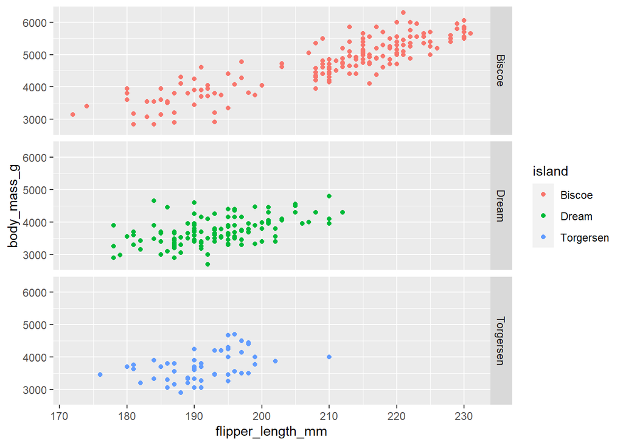

# 3 Gráfico Convex hull

A continuación vamos a ver un ejemplo de cómo utilizar un gráfico Convex hull. Para ello usaremos el data set **iris**. Esta base de datos ha sido presentado por Ronald Fisher en su artículo de 1936 El uso de medidas múltiples en problemas taxonómicos, contiene tres especies de plantas (setosa, virginica, versicolor) y cuatro características medidas para cada muestra. Estos cuantifican la variación morfológica de la flor de iris en sus tres especies, todas las medidas dadas en centímetros.

Este dataset está previamente trabajado para que los datos estén limpios y sin errores. De no ser así antes de nada deberíamos buscar errores, valores nulos u *outliers*.

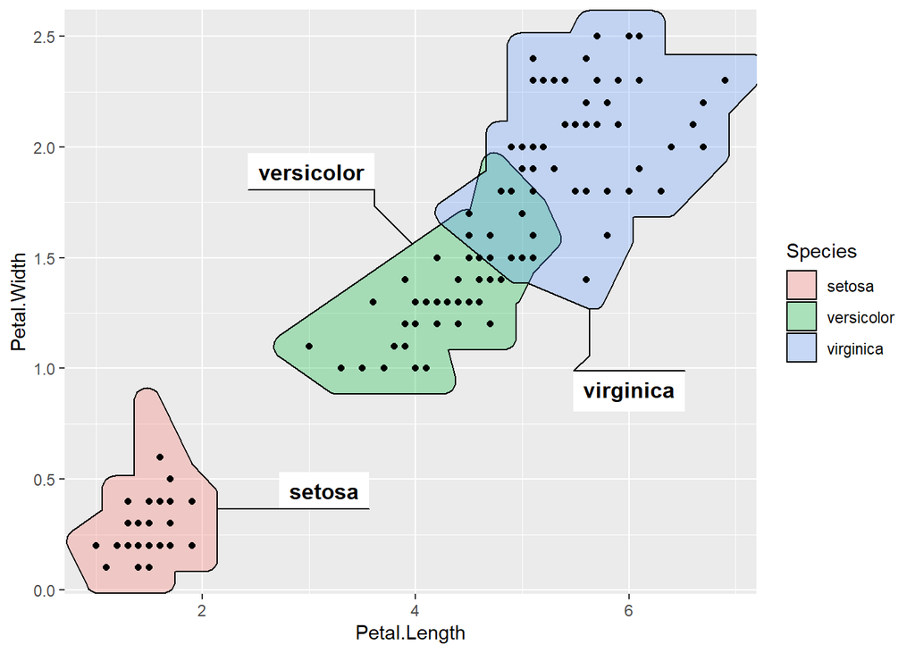

# 4 Gráfico Pyramid Charts

A continuación vamos a ver un ejemplo de cómo utilizar un gráfico Pyramid Charts

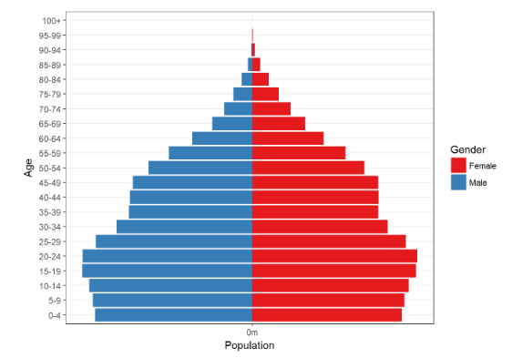

Piramide Poblacional Colombia 2022